# CMCHW2

APPM 4600 HW2 - Charlie Caravati

```python
import numpy as np
import math
import matplotlib.pyplot as plt
```

### 1

> (a)

To show that $x\sin\sqrt{x} = O(x^{3/2})$ as $x \to 0$, we show $\lim_{x \to 0} \frac{f(x)}{g(x)} = M < \infty$ for some positive constant M.

Letting $f(x) = x\sin\sqrt{x}$ and $g(x) = x^{3/2}$

$\lim_{x \to 0} \frac{x\sin\sqrt{x}}{x^{3/2}} = \lim_{x \to 0} \frac{\sin\sqrt{x}}{\sqrt{x}} = 1$ by $\lim_{u \to 0} \frac{\sin{u}}{u}=1$ where $u=\sqrt{x}$. Letting M = 1, $x\sin\sqrt{x} = O(x^{3/2})$ as x -> 0.

> (b)

For $\int_{0}^{\epsilon} e^{-x^2} dx = O(\epsilon)$ as $\epsilon \to 0$, let $f(x) = \int_{0}^{\epsilon} e^{-x^2} dx$ and $g(x) = \epsilon$

$\lim_{\epsilon \to 0} \frac {\int_{0}^{\epsilon} e^{-x^2} dx}{\epsilon} = \lim_{\epsilon \to 0} \frac {\frac{d}{d\epsilon}\int_{0}^{\epsilon} e^{-x^2} dx}{\frac{d}{d\epsilon}\epsilon} = \lim_{\epsilon \to 0} \frac {e^{-\epsilon^2}}{1} = \lim_{\epsilon \to 0} e^{-\epsilon^2} = e^0 = 1$ Letting M = 1 again, $\int_{0}^{\epsilon} e^{-x^2} dx = O(\epsilon)$ as $\epsilon \to 0$

### 2

$Ax = b$ where

$A = \frac{1}{2}\begin{bmatrix} 1 & 1 \\ 1+10^{-10} & 1-10^{-10} \end{bmatrix}$

$b = \begin{bmatrix} 1 \\ 1 \end{bmatrix}$

$x = \begin{bmatrix} 1 \\ 1 \end{bmatrix}$

$A^{-1} = \begin{bmatrix} 1 - 10^{10} & 10^{10}\\ 1+10^{10} & -10^{10} \end{bmatrix}$

$\Delta b = \begin{bmatrix} \Delta b_{1} \\ \Delta b_{2} \end{bmatrix}$

> (a)

Find formula for the change in solution between $x$ and $\Delta{x}$

$A(x + \Delta{x}) = b + \Delta{b}$ gives $Ax + A\Delta{x} = b + \Delta{b}$

Since $Ax=b$, this gives $b + A\Delta{x} = b + \Delta{b} \to A\Delta{x} = \Delta{b} \to \Delta{x} = A^{-1}\Delta{b}$

$\Delta{x} = A^{-1}\Delta{b} = \begin{bmatrix} 1 - 10^{10} & 10^{10}\\ 1+10^{10} & -10^{10} \end{bmatrix} \begin{bmatrix} \Delta b_{1} \\ \Delta b_{2} \end{bmatrix} = \begin{bmatrix} \Delta b_{1} + 10^{10}(\Delta{b_{2}}-\Delta{b_{1}}) \\ \Delta b_{1} - 10^{10}(\Delta{b_{2}}-\Delta{b_{1}})\end{bmatrix}$

(b)

Condition number of A.

$\kappa_2(A) = \|A\|_2 \|A^{-1}\|_2 = \frac{\sigma_{\max}(A)}{\sigma_{\min}(A)} = \sqrt{\frac{\lambda_{\max}(A^T A)}{\lambda_{\min}(A^T A)}}$ where $\lambda$ represents the eigenvalues of $A^{T}A$. Letting $\epsilon = 10^{-10}$ gives

$A = \frac{1}{2}\begin{bmatrix} 1 & 1 \\ 1+\epsilon & 1-\epsilon \end{bmatrix}$ and $A^{T} = \frac{1}{2}\begin{bmatrix} 1 & 1 +\epsilon\\ 1 & 1-\epsilon \end{bmatrix}$

$A^T A = \begin{bmatrix} \frac{1}{2} + \frac{1}{2}\epsilon + \frac{1}{4}\epsilon^2 & \frac{1}{2} - \frac{1}{4}\epsilon^2 \\ \frac{1}{2} - \frac{1}{4}\epsilon^2 & \frac{1}{2} - \frac{1}{2}\epsilon + \frac{1}{4}\epsilon^2 \end{bmatrix}$ gives $\lambda = \frac{1 + \frac{1}{2}\epsilon^2 \pm \sqrt{1 + \frac{1}{4}\epsilon^4}}{2}$

$\kappa_2(A) = \sqrt{\frac{\frac{1 + \frac{1}{2}\epsilon^2 + \sqrt{1 + \frac{1}{4}\epsilon^4}}{2}}{ \frac{1 + \frac{1}{2}\epsilon^2 - \sqrt{1 + \frac{1}{4}\epsilon^4}}{2}}}$ gives

$\kappa_2(A) = \sqrt{\frac{\frac{1 + \frac{1}{2}(10^{-10})^2 + \sqrt{1 + \frac{1}{4}(10^{-10})^4}}{2}}{ \frac{1 + \frac{1}{2}(10^{-10})^2 - \sqrt{1 + \frac{1}{4}(10^{-10})^4}}{2}}} = \sqrt{\frac{\frac{1 + \frac{1}{2}(10^{-20}) + \sqrt{1 + \frac{1}{4}(10^{-40})}}{2}}{ \frac{1 + \frac{1}{2}(10^{-20}) - \sqrt{1 + \frac{1}{4}(10^{-40})}}{2}}} \approx 2 \times 10^{10}$

(c) Let $\Delta{b_1}$ and $\Delta{b_2}$ be of magnitude $10^{−5}$ and not necessarily the same value.

To measure relative error we want to look at the maximum absolute component of $\Delta{x}$ via the infinity norm.

$\Delta{x} = \begin{bmatrix} \Delta b_1 + 10^{10}(\Delta b_2 - \Delta b_1) \\ \Delta b_1 - 10^{10}(\Delta b_2 - \Delta b_1) \end{bmatrix} = \begin{bmatrix} 10^{-5} + 10^{10}(2 \times 10^{-5}) \\ 10^{-5} - 10^{10}(2 \times 10^{-5}) \end{bmatrix} $

Relative error (x) $= \frac{\|\Delta{x}\|_{\infty}}{\|x\|_{\infty}} = \frac{10^{-5} + 10^{10}(2 \times 10^{-5})}{1} = 10^{-5} + 10^{10}(2 \times 10^{-5}) = 200,000.00001$

When the difference between $\Delta{b_1}$ and $\Delta{b_2}$ increases, the large condition number amplifies the relative error drastically as a result. Different values of perturbations are far more likely, which is a cause for concern on this problem.

### 3

$f(x) = e^x-1$

> (a)

The relative condition number $\kappa(f(x)) = |\frac{xf'(x)}{f(x)}|$

$f'(x)=e^x$

$\kappa(f(x)) = |\frac{xe^x}{e^x-1}|$

For $x \to 0$, $\lim_{x \to 0}|\frac{xe^x}{e^x-1}| \approx |\frac{xe^x}{x}|= 1$

For $x \to \infty$, $\lim_{x \to \infty}|\frac{xe^x}{e^x-1}| \approx |\frac{xe^x}{e^x}| = |x|$ which grows linearly to infinity. f(x) is thus ill conditioned for very large x.

> (b)

y = math.e^x

return y-1

This algorithm is not stable because as x decreases to very small values, $\lim_{x \to 0}e^x$ y becomes increasingly close to 1 and subtracting the like terms in step 2 leads to catastrophic cancellation.

> (c)

$x = 9.999999995000000 \times 10^{−10}$ gives $f(x)=10^{-9}$ up to 16 decimal places.

```python
x = 9.999999995000000e-10
y = math.e**x
print (y-1)
print(10e-10)
```

```
1.000000082740371e-09
1e-09
```

The algorithm only gives 7 correct decimal places. The decrease is expected due to the catastrophic cancellation mentioned when x is very small.

> (d)

Taylor series for $f(x) = e^{x}-1 = x + \frac{x^2}{2!} + \frac{x^3}{3!} + ...$

We need Relative error $= |\frac{Exact Value - Polynomial Approx}{Exact Value}| < 10^{-16}$

for n = 2, the first omitted term is $\frac{x^3}{3!}$ which gives RE $\approx \frac{\frac{x^3}{6}}{x} = \frac{x^2}{6}$ for x = 9.999999995000000e-10, this gives RE $\approx 1.67^{-19}$

This gives $f(x) \approx x + \frac{x^2}{2}$

> (e)

```python
x = 9.999999995000000e-10
fx = x + ((x*x)/2)
fx
```

```
1e-09
```

Which verifies $f(x) \approx x + \frac{x^2}{2}$ for $x = 9.999999995000000 \times 10^{−10}$ gives $f(x)=10^{-9}$ below the relative error.

### 4

$2x-1 = \sin{x}$

> (a)

Closed Interval [a,b] on which the equation has root r with IVT proof of r.

$f(x) = 2x - 1 - \sin{x}$

$f(0) = 2(0) - 1 - \sin{0} = 0 - 1 - 0 = -1$ $f(1) = 2(1) - 1 - \sin{1} = 2 - 1 - .841 = .159$

Since f(0) < 0 and f(1) > 0, there is a root r on the interval [0,1]. Since f(x) is continuos and the function is bounded by f(0) = -1 and f(1) = .159, there must be a root r such that f(r) = 0.

> (b)

the value of the derivative f'(x) = 2 - cos(x) will always stay above or equal to 1 for any x as cosign is bounded [-1,1], which means the function is strictly increasing for all x. A strictly increasing function can only cross y=0 once, which we identified above.

> (c)

```python
def bisect(a, b, func, tol):
    """
    f,a,b   - function and endpoints of initial interval
#   tol     - bisection stops when interval length < tol
    """

    # first verify there is a root we can find in the interval

    fa = func(a)
    fb = func(b)

    if (fa*fb>0):
        ier = 1
        astar = a
        return [astar, ier, "Not in interval"]

    # verify end points are not a root
    if (fa == 0):
        astar = a
        ier =0
        return [astar, ier, "A is a root"]

    if (fb ==0):
        astar = b
        ier = 0
        return [astar, ier, "B is a root"]

    count = 0
    d = .5 * (a + b)
    while (abs(d-a)> tol):
        fd = func(d)
        if (fd ==0):
            astar = d
            ier = 0
            return [astar, ier, count]
        if (fa*fd<0):
            b = d
        else:
            a = d
            fa = fd
        d = .5 * (a+b)
        count = count +1
    astar = d
    ier = 0
    return [astar, ier, count]
```

```python
root, ier, iters = bisect(0,1,lambda x: 2*x - 1 - np.sin(x),1e-8)

if ier == 0:
    print("The root is:", root)
    print("The count is:", iters)
else:
    print("No root found")
```

```
The root is: 0.8878622129559517
The count is: 26
```

### 5

> (a)

Upper bound on iterations for bisection needed to approximate $x^3 + x - 4 = 0$ lying in [1,4] with accuracy $10^{-3}$ Since f(x) is continuos over the interval and f(a)f(b) < 0, bisection generate a sequence of approximations converging to the root r such that $|r-x_n| \leq \frac{b-a}{2^n}$. For accuracy $10^{-3}$, set $\frac{b-a}{2^n} \leq tol$ gives

$\frac{4-1}{2^n} \leq 10^{-3} \to \frac{3}{2^n} \leq \frac{1}{1000} \to 2n \geq 3000 \to n \geq \log_{2}(3000) = \frac{ln(3000)}{ln(2)} \approx 11.55$ upper bound for number of iterations.

> (b)

The code finds the root 1.380859375 in 8 iterations, which is under the upper bound determined above.

```python
root, ier, iters = bisect(1,4,lambda x: x**3 + x -4,1e-2)

if ier == 0:
    print("The root is:", root)
    print("The count is:", iters)
else:
    print("No root found")
```

```
The root is: 1.380859375
The count is: 8
```

### 6

> (a)

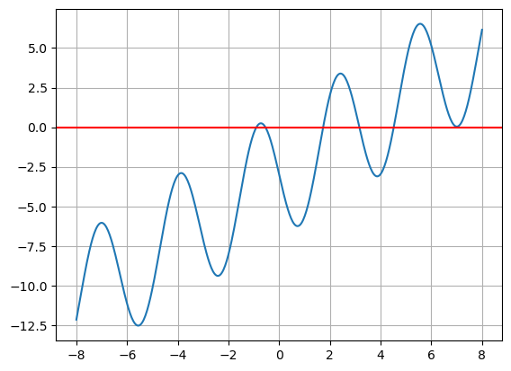

```python
x = np.linspace(-8, 8, 500)
y = x - 4 * np.sin(2 * x) - 3

plt.plot(x, y)
plt.axhline(0, color='red', linestyle='-')
plt.grid(True)
plt.show()
```

There are 5 crossings.

> (b)

$x_{n+1} = -\sin{(2x_n)} + \frac{5x_n}{4} - \frac{3}{4}$

```python
def fixedpt(x0, f,tol,Nmax):

    ''' x0 = initial guess'''
    ''' Nmax = max number of iterations'''
    ''' tol = stopping tolerance'''

    count = 0
    v = []

    while (count <Nmax):
       count = count +1
       x1 = f(x0)
       v.append(x1)
       if (abs(x1-x0) <tol):
          xstar = x1
          ier = 0
          vec_full = np.array(v)
          return [xstar, ier, vec_full]
       vec_full = np.array(v)
       x0 = x1
    xstar = x1
    ier = 1
    return [xstar, ier, vec_full]
```

```python
root1, ier, vector = fixedpt(-1, lambda x: -np.sin(2*x) + (5*x)/4 - 3/4, 1e-9, 100)

if ier == 0:
    print("The root is:", root1)
else:
    print("No root found")
```

```
No root found
```

```python
root2, ier, vector = fixedpt(0, lambda x: -np.sin(2*x) + (5*x)/4 - 3/4, 1e-9, 100)

if ier == 0:
    print("The root is:", root2)
else:
    print("No root found")
```

```
The root is: -0.5444424009452844
```

```python
root3, ier, vector = fixedpt(1.8, lambda x: -np.sin(2*x) + (5*x)/4 - 3/4, 1e-9, 100)

if ier == 0:
    print("The root is:", root3)
else:
    print("No root found")
```

```
The root is: 3.1618264861802765
```

```python
root4, ier, vector = fixedpt(5, lambda x: -np.sin(2*x) + (5*x)/4 - 3/4, 1e-9, 100)

if ier == 0:
    print("The root is:", root4)
else:
    print("No root found")
```

```
No root found
```

The fixed point method is only able to find 2 of the 5 roots due to the requirement that the absolute value of the derivative must be less that 1 at the root for convergence. For 3 of the roots, the derivative is greater than 1.